# The Phillips curve in NZ

Taylor Winter

31 January 2018

## Overview

The [Phillips curve](https://en.wikipedia.org/wiki/Phillips_curve) is basically the negative correlation between inflation (Capital Price Index; CPI) and unemployment. One basic explanation of this is that when unemployment drops the resulting competition for labour drives wage increases leading to increased CPI. After seeing an article on [The Economist](https://www.economist.com/blogs/graphicdetail/2017/11/daily-chart) indicating that this correlation may not hold in present United States, I was curious if the Phillips Curve could still be observed in New Zealand.

## Data background

The data comes as an excel spreadsheet from the [Reserve Bank](https://www.rbnz.govt.nz/statistics/key-graphs/key-graph-inflation) and a CSV from [Stats Nz](http://archive.stats.govt.nz/infoshare/SelectVariables.aspx?pxID=caecaca0-2e11-45bf-ba3c-6b08da2ec9ef). They are both quarterly series and can come in seasionally adjusted and unadjusted flavours. In this analysis the CPI is adjusted and unemployment is unadjusted. This is only so I can test out seasonal adjustment and see how it stacks up to the official adjusted series.

## Load and clean data

A little bit of cleaning was needed before merging the data and creating a time series object (cleaning code is in the github project). In the `ts()` function the frequency is the number of observations a year (quarterly) and I set a start date (optional) so graphs make more sense. Henceforth the data works like a matrix rather than a dataframe, it took me longer than it should have to realise that.

```r
dat <- ts(dat, frequency = 4, start=c(1986, 01))
```

Now we can peak at the data and it seems like there is a fairly clear relationship between CPI and unemployment, i.e. a Phillips curve. Seasonally adjusting unemployment then doing some testing will clarify things though.

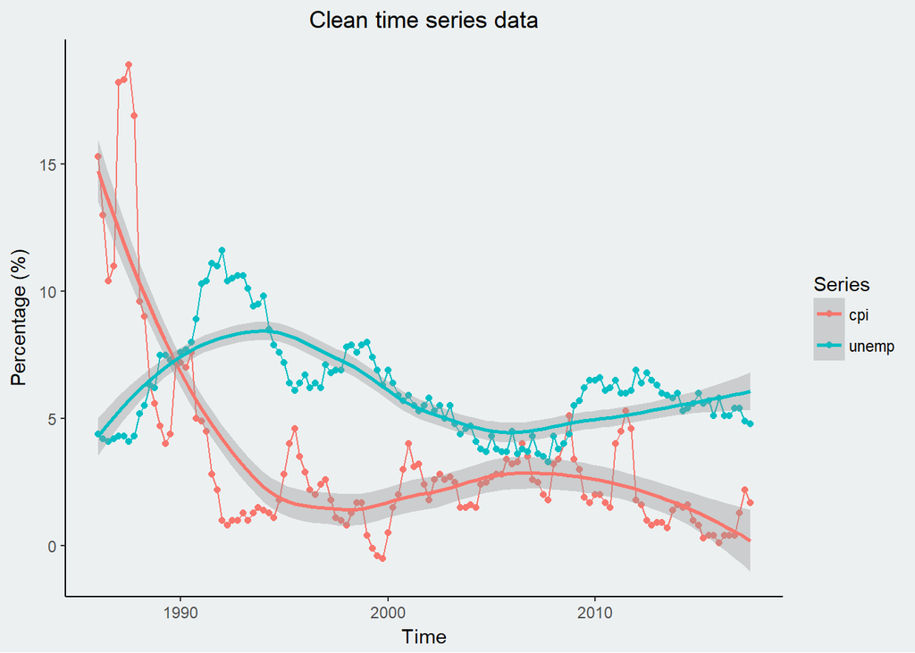

## Seasonally adjust unemployment

The easiest way to seasonally adjust is using a sweet package called `seasonal`. It draws on software developed by the US Census Bureau and is an industry standard in official statistics (including at Stats NZ). I found it works right out of the box as below and you can call the adjusted series using `final()` on the `seas` object.

```r
#Gets adjusted values for unemp and adds them to the dataset using ts.union
dat <- ts.union(dat, "unempAdj" = final(seas(dat[,"unemp"])))
```

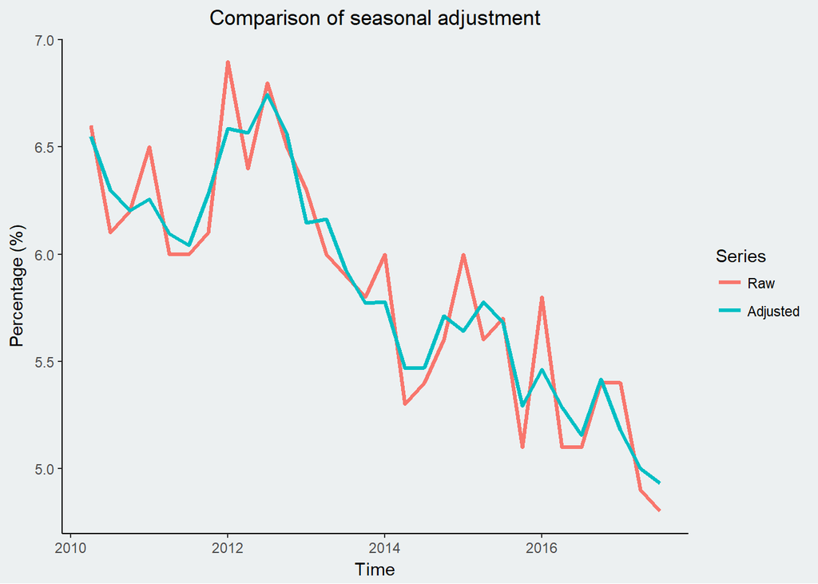

## Is there evidence of the Phillip’s curve?

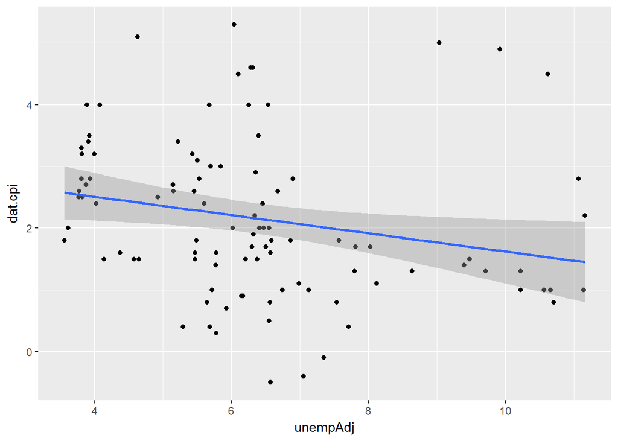

```r
ggplot(as.data.frame(dat[20:120,]), aes(x=unempAdj, y=dat.cpi)) +
  geom_point() +
  geom_smooth(method='lm', formula=y~x)
```

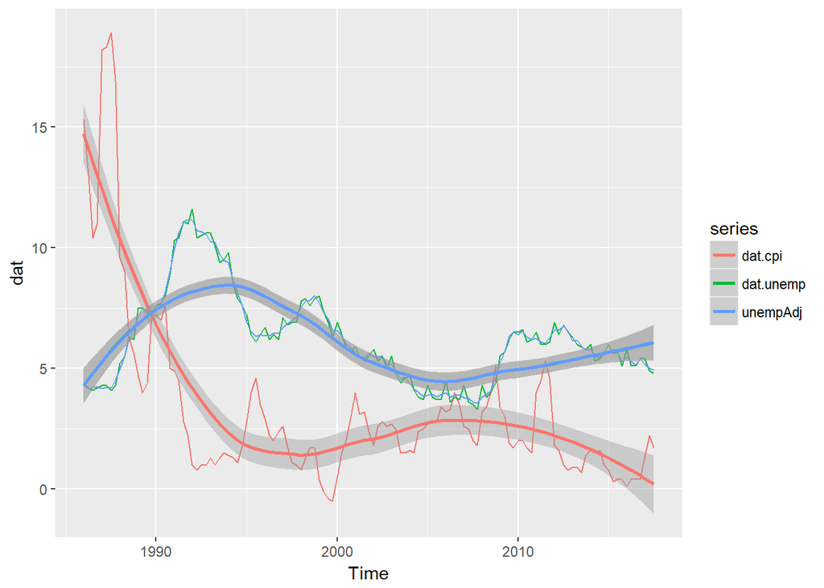

```r
autoplot(dat) +geom_smooth()
```